# Introduction to the evreg package

Thierry Denoeux

2024-05-09

The `evreg` package implements ENNreg (Denœux 2022) (Denœux 2023a), a neural network model for regression in which prediction uncertainty is quantified by Gaussian random fuzzy numbers (GRFNs), a newly introduced family of random fuzzy subsets of the real line that generalizes both Gaussian random variables and Gaussian possibility distributions (Denœux 2023b). The output GRFN is constructed by combining GRFNs induced by prototypes using a combination operator that generalizes Dempster’s rule of Evidence Theory. The three output units indicate the most plausible value of the response variable, variability around this value, and epistemic uncertainty. The network is trained by minimizing a loss function that generalizes the negative log-likelihood.

The `evreg` package contains functions for training the ENNreg model in batch or online mode, tuning hyperparameters by cross-validation or the hold-out method, and making predictions. It also contains utilities for making calculations with GRFNs (such as, e.g., computing the degrees of belief and plausibility of an interval, or combining GRFNs).

The user is invited to read the papers cited in this vignette to get familiar with the main concepts underlying epistemic random fuzzy sets and evidential regression. These papers can be downloaded from the author’s web site, at https://www.hds.utc.fr/~tdenoeux/. Here, we provide a short guided tour of the main functions in the `evreg` package.

You first need to install this package:

```r
library(evreg)
```

The following sections contain a brief introduction on the way to use the main functions in the package `evreg` for evidential regression.

## Evidential regression

### Data generation

Let us start by writing a function that generates a dataset similar to that used in Section V.A of (Denœux 2023a):

```r
gendat<-function(n){
  x<-rep(0,n)
  y<-x
  for(i in 1:n){
    u<-runif(1)
    if(u<0.5) x[i]<-runif(1,-3,-1) else x[i]<-runif(1,1,4)
    if(x[i]<0) y[i] <- sin(3*x[i])+ x[i]+ sqrt(0.01)* rnorm(1)
      else y[i] <- sin(3*x[i])+ x[i]+ sqrt(0.3)* rnorm(1)
  }
  return(list(x=x,y=y))
}
```

We generate training and test sets of sizes, respectively, 400 and 1000:

```r
n<-400
nt<-1000
set.seed(20230104)
train<-gendat(n)
test<-gendat(nt)
```

### Hyperparameter tuning and learning

Let us determine hyperparameters $\xi$ and $\rho$ using cross-validation, with batch training and $K=30$ prototypes:

```r
cv<-ENNreg_cv(train$x,train$y,K=30,XI=c(0,0.01,0.1),RHO=c(0,0.01,0.1),verbose=FALSE)
cv
```

```
## $xi
## [1] 0
##
## $rho
## [1] 0.1
##
## $RMS
##           [,1]      [,2]      [,3]
## [1,] 0.4976374 0.4616553 0.4520943
## [2,] 0.4994927 0.4541761 0.4580496
## [3,] 0.4897193 0.4546863 0.4673519
```

We can then train again the model using all the training data and the selected hyperparameters:

```r
fit<-ENNreg(train$x,train$y,K=30,xi=cv$xi,rho=cv$rho,verbose=FALSE)
```

Let us now compute the predictions for regularly spaced inputs:

```r
xt<-seq(-4,5,0.01)
pred<-predict(fit,xt)
```

and let us compute belief intervals at levels 50%, 90% and 99%:

```r
int50<-intervals(pred,0.50)
int90<-intervals(pred,0.9)
int99<-intervals(pred,0.99)
```

We can now plot the results using function `ggplot` of package ``ggplot2`:

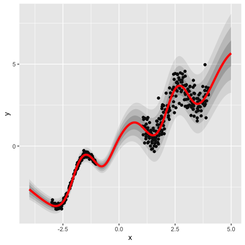

```r
library(ggplot2)
int<-data.frame(lwr50=int50$INTBel[,1],upr50=int50$INTBel[,2],
                lwr90=int90$INTBel[,1],upr90=int90$INTBel[,2],
                lwr99=int99$INTBel[,1],upr99=int99$INTBel[,2],
                x=xt,mux=pred$mux)
ggplot(data=as.data.frame(train), aes(x = x)) +
  geom_point(aes(y = y)) +
  geom_ribbon(data=int, aes(ymin = lwr50, ymax = upr50,x=x),alpha=0.2)+
  geom_ribbon(data=int, aes(ymin = lwr90, ymax = upr90,x=x),alpha=0.15)+
  geom_ribbon(data=int, aes(ymin = lwr99, ymax = upr99,x=x),alpha=0.1) +
  geom_line(data=int,aes(x = x,y=mux),color="red",linewidth=1.5)
```

### Calibration curves

Let us now plot calibration curves for probabilistic and belief prediction intervals. We start by computing the predictions for the test set:

```r
pred.tst<-predict(fit,test$x,test$y)
```

We then compute belief intervals with their coverage rates and plausibilities for 9 equally spaced levels between 0.1 and 0.9:

```r
A<-seq(0.1,0.9,0.1)
nA<-length(A)
probbel<-rep(0,nA)
plbel<-rep(0,nA)
for(i in 1:nA){
  int<-intervals(pred.tst,A[i],test$y)
  probbel[i]<-int$coverage.Bel
  plbel[i]<-int$Pl.Bel
}
```

Finally, we can plot the calibration curves:

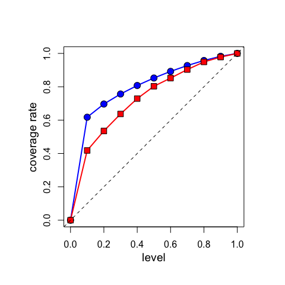

```r
oldpar <- par(pty="s")
plot(c(0,A,1),c(0,plbel,1),type="l",lwd=2,col="blue",xlab="",ylab="")
points(c(0,A,1),c(0,plbel,1),pch=21,bg="blue",cex=1.5)
lines(c(0,A,1),c(0,probbel,1),col="red",lwd=2)
points(c(0,A,1),c(0,probbel,1),pch=22,bg="red",cex=1.5)
abline(0,1,lty=2)
title(ylab="coverage rate", line=2.2, cex.lab=1.2)
title(xlab="level", line=2.2, cex.lab=1.2)
```

```r
par(oldpar)
```

## Calculations with Gaussian random fuzzy numbers

The `evreg` package also contains functions for computing with, and combining GRFNs. For instance, functions `Bel` and `Pl` compute, respectively, the degrees of belief and plausibility of intervals $[x,y]$. Let us illustrate the use of these functions for plotting $Bel([x-r,x+r])$ and $Pl([x-r,x+r])$ as functions of $x$, for different values of $r$. We start by defining the GRFN:

```r
GRFN<-list(mu=1,sig=0.5,h=1)
```

We can then draw the “belief plot”:

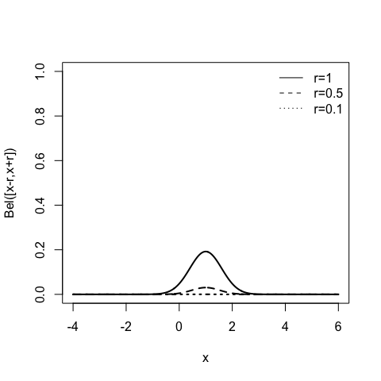

```r
x<-seq(-4,6,0.01)
plot(x,Bel(x-1,x+1,GRFN),type="l",xlab="x",ylab="Bel([x-r,x+r])",
     lwd=2,ylim=c(0,1))
lines(x,Bel(x-0.5,x+0.5,GRFN),lwd=2,lty=2)
lines(x,Bel(x-0.1,x+0.1,GRFN),lwd=2,lty=3)
legend("topright",legend=c("r=1","r=0.5","r=0.1"),lty=c(1,2,3),bty="n")
```

and the “plausibility plot”:

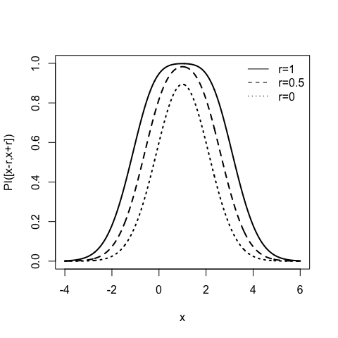

```r
plot(x,Pl(x-1,x+1,GRFN),type="l",xlab="x",ylab="Pl([x-r,x+r])",lwd=2,ylim=c(0,1))
lines(x,Pl(x-0.5,x+0.5,GRFN),lwd=2,lty=2)
lines(x,pl_contour(x,GRFN),lwd=2,lty=3)
legend("topright",legend=c("r=1","r=0.5","r=0"),lty=c(1,2,3),bty="n")
```

We can also plot the lower cumulative distribution function (cdf) $F_*(x)=Bel((-\infty,x])$ and the upper cdf $F^*(x)=Pl((-\infty,x])$ as follows:

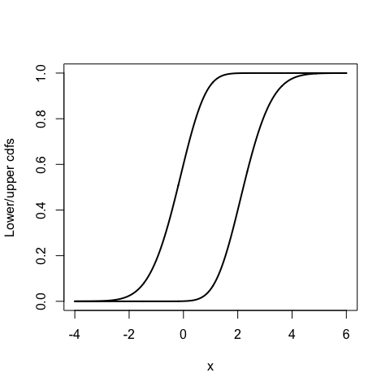

```r
plot(x,Bel(-Inf,x,GRFN),type="l",xlab="x",ylab="Lower/upper cdfs",lwd=2)
lines(x,Pl(-Inf,x,GRFN),type="l",lwd=2)
```

Finally, `evreg` also has a function `combination_GRFN` that combines GRFNs using the generalized product-intersection rule with hard or soft normalization. The rule with soft normalization was introduced in (Denœux 2023b) and is recommended because it has very appealing properties (the contour function of the combined random fuzzy sets is still proportional to the product of the controur functions, a very useful property of Dempster’s rule preserved with soft normalization). However, the combination rule with hard normalization is simpler to compute and is implemented in the ENNreg model (Denœux 2023a). Here is an illustration of the use of function `combination_GRFN` with the two normalization schemes. Let us first define two GRFNs:

```r
GRFN1<-list(mu=0,sig=2,h=4)
GRFN2<-list(mu=1,sig=1,h=1)
```

and combine them with soft and hard normalization:

```r
GRFN12s<-combination_GRFN(GRFN1,GRFN2,soft=TRUE)
GRFN12h<-combination_GRFN(GRFN1,GRFN2,soft=FALSE)
print(GRFN12s$GRFN)
```

```
## $mu
## [1] 0.68
##
## $sig
## [1] 1.077033
##
## $h
## [1] 5
```

```r
print(GRFN12h$GRFN)
```

```
## $mu
## [1] 0.2
##
## $sig
## [1] 1.612452
##
## $h
## [1] 5
```

We can see that the results are quite different. Here is a plot of the contour functions of the initial and combined GRFNs:

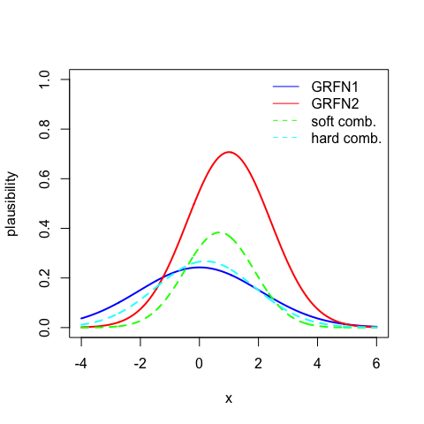

```r
x<-seq(-4,6,0.01)
plot(x,pl_contour(x,GRFN1),type="l",xlab="x",ylab="plausibility",lwd=2,
     ylim=c(0,1),col="blue")
lines(x,pl_contour(x,GRFN2),lwd=2,lty=1,col="red")
lines(x,pl_contour(x,GRFN12s$GRFN),lwd=2,lty=2,col="green")
lines(x,pl_contour(x,GRFN12h$GRFN),lwd=2,lty=2,col="cyan")
legend("topright",legend=c("GRFN1","GRFN2","soft comb.","hard comb."),
       lty=c(1,1,2,2),bty="n",col=c("blue","red","green","cyan"))
```

## References

Denœux, Thierry. 2022. “An Evidential Neural Network Model for Regression Based on Random Fuzzy Numbers.” In *Belief Functions: Theory and Applications*, edited by Sylvie Le Hégarat-Mascle, Isabelle Bloch, and Emanuel Aldea, 57–66. Cham: Springer International Publishing.

———. 2023a. “Quantifying Prediction Uncertainty in Regression using Random Fuzzy Sets: the ENNreg model.” *IEEE Transactions on Fuzzy Systems* 31: 3690–99.

———. 2023b. “Reasoning with Fuzzy and Uncertain Evidence Using Epistemic Random Fuzzy Sets: General Framework and Practical Models.” *Fuzzy Sets and Systems* 453: 1–36.